# NYPD Shooting Incident Project

There also appears to be a steeper decline in male victim incidents when compared to female victims. There are observations that don’t fall either in M or F category, but those values are minimal. The number of incidents for both male and female victims spiked in 2020.

```r
totals_by_month_sex <- nypd_shootings %>%
  group_by(VIC_SEX,monthly_date = floor_date(OCCUR_DATE, "month")) %>%
  summarize(Inc_per_sex = n())
```

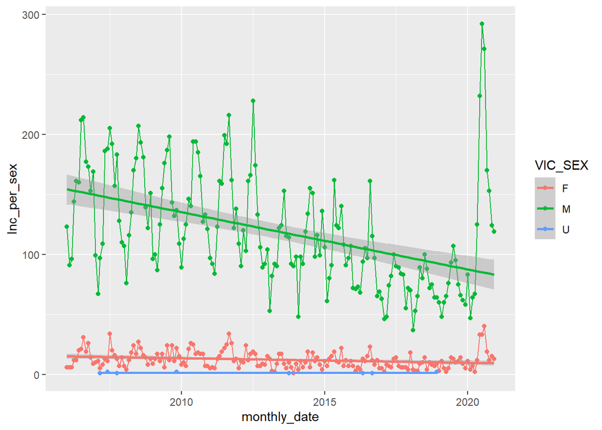

```r
ggplot(totals_by_month_sex, aes(x=monthly_date, y=Inc_per_sex, color=VIC_SEX))+
  geom_line()+
  geom_point()+
  geom_smooth(method=lm)
```

I was also interested to see the number of shooting incidents per month broken out by borough.

```r
incidents_by_boro_by_month <- nypd_shootings %>%
  group_by(BORO,monthly_date = floor_date(OCCUR_DATE, "month")) %>%
  summarize(Inc_per_boro = n())
```

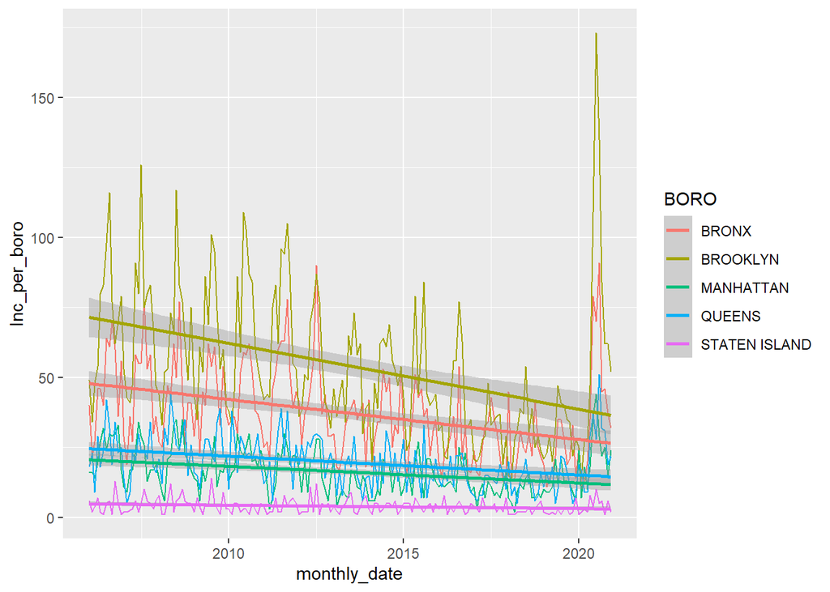

```r
ggplot(incidents_by_boro_by_month, aes(monthly_date, Inc_per_boro, color = BORO))+
  geom_line()+
  geom_smooth(method=lm)
```

The recent spike in the number of incidents warrants more investigation, so I filtered the borough data to only show incidents from Jan 1, 2020 on. The plot shows a spike in the number of incidents in the summer months for every borough, though it’s much less pronounced in Staten Island. This timeline not only coincides with the seasonality observed previously, but also the pandemic and protests that were going on across the US. I can’t conclusively say those factors caused the spike from this data set, making an observation.

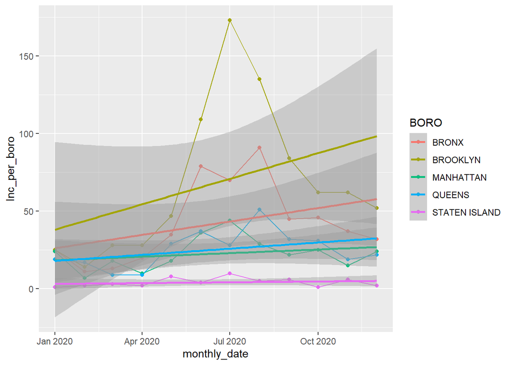

```r
beyond_2020 <- incidents_by_boro_by_month %>%
  filter(monthly_date >= as.Date("2020-01-01"))

ggplot(beyond_2020, aes(monthly_date, Inc_per_boro, color = BORO))+
  geom_line()+
  geom_point()+
  geom_smooth(method=lm)
```

# Conclusion and Bias Identification

## Conclusion:

Firstly, whatever was being done to decrease the number of shooting incidents prior to the summer of 2020 seems like it was having a positive impact. Progress was being made, and even though the system wasn’t perfect, it appears as though there were policies and practices in place that were helping to decrease the total number of incidents across all boroughs. It would require further analysis, but perhaps the fact that the discrepancy in number of incidents was becoming smaller between the boroughs is a positive indicator of other achievements, such as income equality, education equality, etc.

Secondly, the data suggests that NYC was not prepared to properly respond to the incidents that unfolded in the summer of 2020 (not just NYC I’m sure). That should be considered when putting together future contingency plans.

## Bias identification

Who collects this data is a source of bias that needs to be considered. The description on the website says it’s a list of “every shooting incident that occurred in NYC”. We know that’s not true, it’s only a list of every shooting incident collected by the NYPD. So we know there are incidents that were not reported to the NYPD - but without additional information we don’t know if the number of unreported incidents were disproportionately high for certain boroughs, victim demographics, etc. It’s possible this data is skewed, but without additional information no adjustments can be made.

I found that both age and sex of perps and victims could potentially introduce personal bias in my analysis. Before analyzing the data, I assumed that both female victims and perps would be minimal, and that as the age groups for perp & victim went up the number of incidents would decrease. I didn’t perform an analysis based on age, and didn’t analyze perp sex as there was too much missing data, but did analyze victim sex. As it turns out, there were far fewer female victims than male, but good to note where the possibility for bias could come into play. I didn’t perform any additional analysis that would require adjustment for my personal bias.